# Final Report

# Team members: Carter Athens, Max Ruehle, Zihao Han

## Project coordinator: Carter Athens

Link to the data source: https://www.kaggle.com/ramamet4/app-store-apple-data-set-10k-apps

### Loading in the data

```r
AppleStore <- read.csv(file="AppleStore.csv", header=TRUE, sep=",")
head(AppleStore, 5)
```

```
##   X        id                                         track_name
## 1 1 281656475                                    PAC-MAN Premium
## 2 2 281796108                          Evernote - stay organized
## 3 3 281940292    WeatherBug - Local Weather, Radar, Maps, Alerts
## 4 4 282614216 eBay: Best App to Buy, Sell, Save! Online Shopping
## 5 5 282935706                                              Bible
##   size_bytes currency price rating_count_tot rating_count_ver user_rating
## 1  100788224      USD  3.99            21292               26         4.0
## 2  158578688      USD  0.00           161065               26         4.0
## 3  100524032      USD  0.00           188583             2822         3.5
## 4  128512000      USD  0.00           262241              649         4.0
## 5   92774400      USD  0.00           985920             5320         4.5
##   user_rating_ver    ver cont_rating  prime_genre sup_devices.num
## 1             4.5  6.3.5          4+        Games              38
## 2             3.5  8.2.2          4+ Productivity              37
## 3             4.5  5.0.0          4+      Weather              37
## 4             4.5 5.10.0         12+     Shopping              37
## 5             5.0  7.5.1          4+    Reference              37
##   ipadSc_urls.num lang.num vpp_lic
## 1               5       10       1
## 2               5       23       1
## 3               5        3       1
## 4               5        9       1
## 5               5       45       1
```

### Cleaning the data

The currency column only contains the value “USD” so it was dropped. Also columns vpp_lic, ver, and id are unnecessary/ meaningless. Then we need to drop any rows that contain invalid info.

```r
df = subset(AppleStore, select = -c(currency, vpp_lic, ver, id))
dfCleaned <- df[complete.cases(df), ]
```

### Some questions this data set can answer

Which types of apps get the best ratings?

Do free apps or paid apps get better ratings?

How do some of our most frequently used apps, mainly social media and music apps, compare to each other and other apps of their type?

What are some very expensive apps and how they compare to the rest of the apps?

What are some visualizations for apps and ratings based on their price?

### Challenges faced

The number of downloads for each app was not available. This would have been nice to see the ratio of downloads to number of ratings.

This dataset only included Apple App Store apps. Google Play Store apps were not included.

This dataset only contains the price and rating that are useful to analysis Once we get deeper analysis such as what influence the data, we find out that we don’t have enough data

Some of the Apps’ name track_name in this dataset are shown as some unrecognizable characters and become useless.

### Findings

#### Which types of apps get the best ratings?

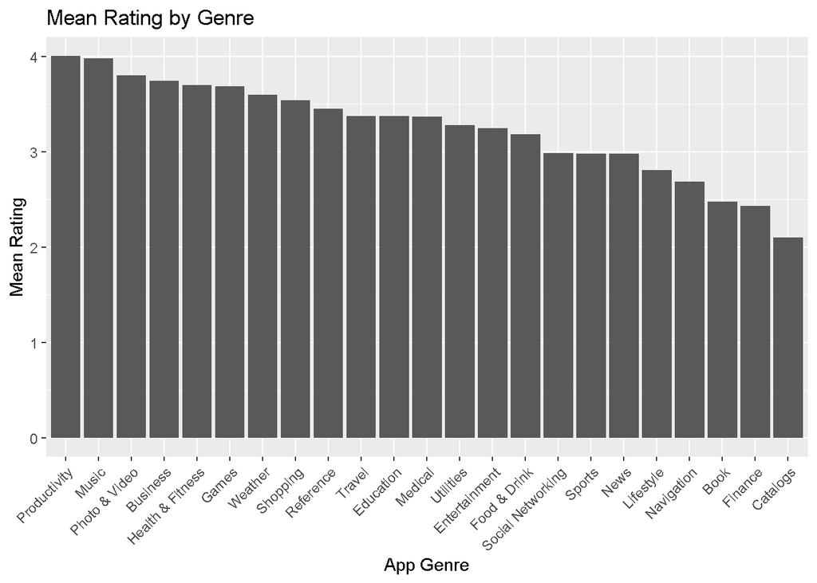

As seen by the chart above, the top three app genres are Productivity, Music, and Photo & Video. Productivity apps are the highest probably because people get them to complete a task, and are usually satisfied if it helped.

#### Do free apps or paid apps get better ratings?

```
## # A tibble: 2 x 5
##   price mean_rating total_ratings number_of_apps mean_num_of_ratings
##   <fct>       <dbl>         <int>          <int>               <dbl>
## 1 Free         3.38      80105208           4056              19750.
## 2 Paid         3.72      12685045           3141               4039.
```

On average, paid apps got better ratings than free apps did. This is most likely due to the fact that if people spend money on an app, they usually want to feel satisfied with it. They will then give the app a nice rating.

```
##           track_name price rating_count_tot user_rating
## 94       iSwap Faces  1.99             2302         3.5
## 107 iSwap Faces LITE  0.00            39722         3.0
```

This table shows a lite and a paid version of an app. It shows that even though the free version got much more ratings, the paid version got better ratings. When people get the full product, they tend to be happier.

#### How do some of our most frequently used apps, mainly social media and music apps, compare to each other and other apps of their type?

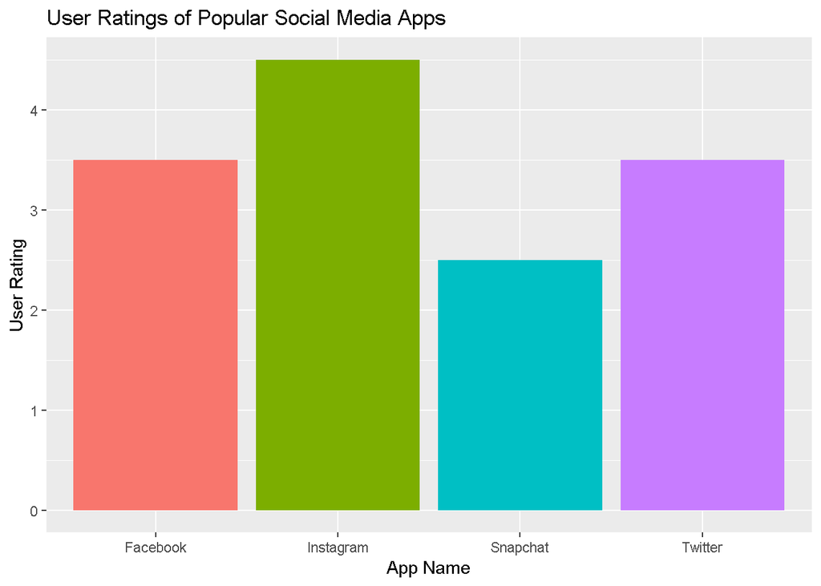

```
##    Min. 1st Qu.  Median    Mean 3rd Qu.    Max.
##   0.000   2.500   3.500   2.985   4.000   5.000
```

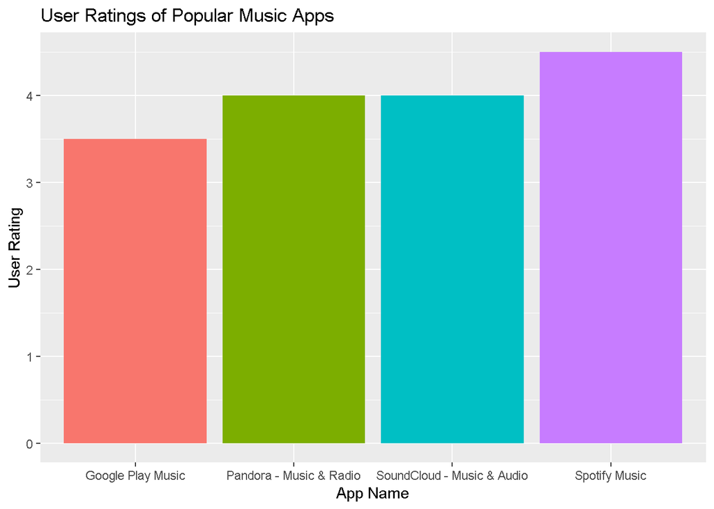

```
##    Min. 1st Qu.  Median    Mean 3rd Qu.    Max.
##   0.000   4.000   4.000   3.978   4.500   5.000
```

Of the four big social media apps, Instagram has the best ratings while Snapchat has the lowest. The average rating of all social media apps is 2.985, meaning Snapchat was actually below average. Spotify has the highest ratings of the four music apps, while Google Play Music has the slowest. The average rating of all music apps is 3.978, so Google Play Music was the only app that was below average.

#### What are some very expensive apps and how they compare to the rest of the apps?

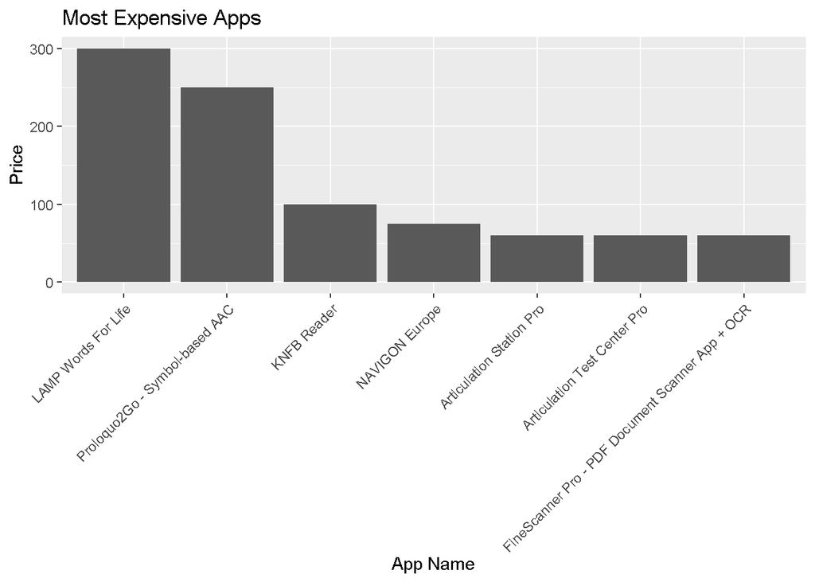

These are the 7 most expensive apps on the App Store. Four of them are education apps. The top two apps are augmented and alternative communication apps, both with 4.0 ratings. The 814 ratings for the two top apps equates to $205,541.86 spent. That is just the money spent for the people who rated the apps. We don’t know how many people downloaded apps to know how much money was actually spent on the app.

What are some visualizations for apps and ratings based on their price?

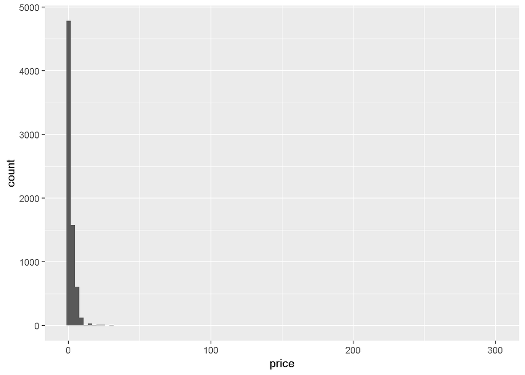

This is a histogram of the price of all apps. It is heavily skewed right with most apps costing nothing.

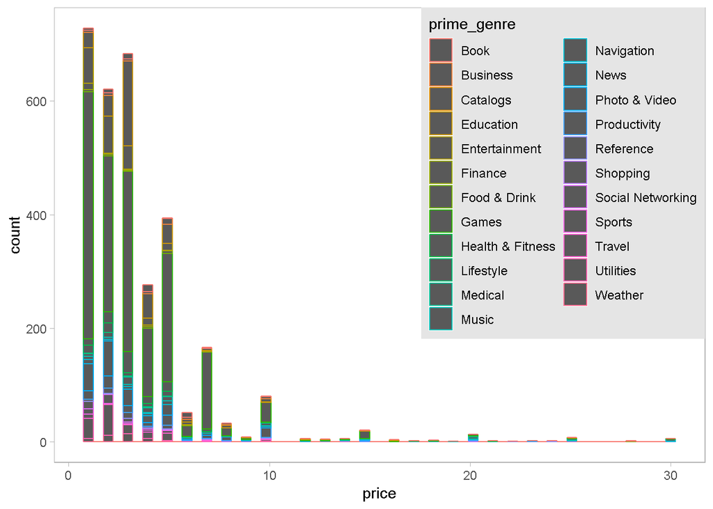

This graph shows a visual of apps priced greater than $0 and less than $30 based on their genre. A large chunck of the apps are games. This visual is still skewed right, meaning more apps are closer to $1.

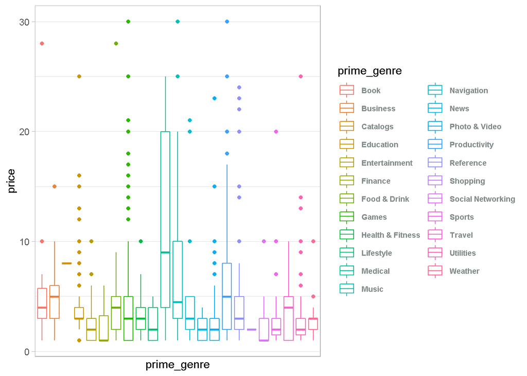

This graph shows the same apps as the histogram, but as boxplots for price based on their genre. The largest box is the Medical genre. There are very little medical apps but they vary in price by a lot.

```
## geom_path: Each group consists of only one observation. Do you need to
## adjust the group aesthetic?
```

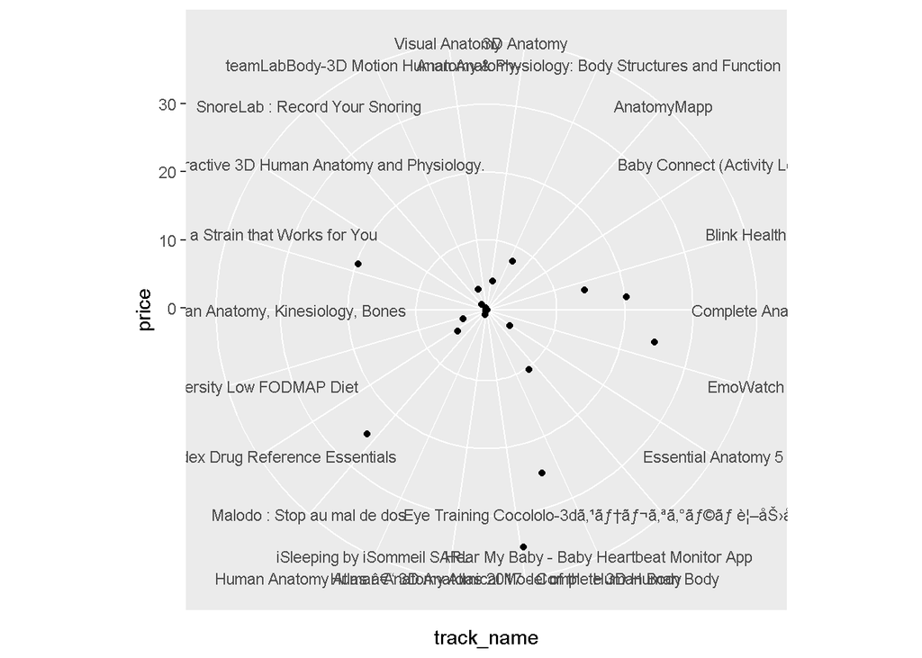

This visualization shows the medical apps based on their price. It is interesting because medical apps are some of the most expensive apps. Many apps are floating around the $5 to $20 range.

### Personal Contributions

Carter Athens: I helped with the initial proposal of the project by finding the data set and cleaning it. I explored data involving the average ratings of each app genre for paid and unpaid apps to find out how they compare. I explored how some of our most frequently used apps, mainly social media and music apps, compare to each other and other apps of their type. I explored data about the average total rating count of each genre. I also created some of the slides for the presentation.

Zihao Han:I set up the ppt.At the begining of the presentation part, we have face the proble that this data set might have too much limits but I make some of the question in to multiple part so that we could break down the question and also we can tell everyone that what we did and how we thought in each part. The thinking procese of how we came up and solve the questions is the most improtant part. So I did the data analysis of the price of the apps.For this part, I did the summary of the data and see how is the statistical part tells us then do the visualization that tells us how it looks. I did the average price of apps analysis first, and will I put the “colour=prime_gener”in to the ggplot, the other question cames up, “is there any relationship between app type and price?”. then I do the gern vs. price analysis. and it show the “medical” cost more money than others, so I did the price vs. each medical app visualiation. While I do the analysis, I found that there are alot unrecongnized app in the data, so I went back do the data clean.

Max Ruehle: For this project, I initially helped with setting up and organizing the outline for the presentation. I took 5 of the questions that we had on the project proposal and edited them a bit to get the five questions that we ended up answering. Of the questions, I worked on the which apps got the best ratings, paid vs free apps, and the expensive apps. The most difficult part was how to visualize the free vs paid apps but in the end it ended up working out.

### Works Cited

Ramanathan. “Mobile App Store ( 7200 Apps).” Kaggle, 10 June 2018, www.kaggle.com/ramamet4/app-store-apple-data-set-10k-apps.

### Conclusion

Productivity apps are, on average, the highest rated apps. The mean ratings for paid apps are, on average, higher than free apps. People actually buy apps that cost more than $50. Of the four big social media apps, Instagram has the best ratings while Snapchat has the lowest. Spotify has the highest ratings of the four music apps, while Google Play Music has the lowest. The price of apps are skewed heavily right. There are lots of free apps.